# Missing data simulation & tests

Atakan_Akgun, Aylin Karapanar

2025-11-22

# Set-up

We first load the required R libraries for data manipulation, visualization, and handling missing data.

```r
# Get needed libraries
library(dplyr)
library(tidyr)
library(lubridate)
library(ggplot2)
library(naniar)
library(mice)
library(gridExtra)
```

#1) Load and Prepare Data

```r
df <- read.csv("./Simulated Data/Mock_Mosquito_MixedEffects_w_slopes_Dataset.csv")
df$Trap_type = factor(df$Trap_type)
df$Mosquito_species = factor(df$Mosquito_species)
df <- df %>%
  mutate(
    SiteDateID = paste(City, Site, Sampling_date, sep = "_")
  )

# for MAR mechanism (realistic: more rain -> trap failure)
# Rainfall is correlated with Relative_humidity to be plausible
df <- df %>%
  mutate(
    Rainfall_mm = round(pmax(0, rnorm(n(), mean = (Relative_humidity - 50) * 0.6 + 2, sd = 8)), 1)
  )

# Keep a copy of the complete "truth" to compare later
truth <- df
```

# 2) MCAR: Weather data logger battery dies at random times

We randomly select a proportion of site-dates where the weather logger fails, causing missing data completely at random (MCAR).

```r
# Mechanism: for a random 8% of site-dates, the logger battery dies and we lose Weather columns:
prop_mcar <- 0.05
site_dates <- unique(df$SiteDateID)
mcar_ids <- sample(site_dates, size = round(length(site_dates) * prop_mcar), replace = FALSE)

df_mcar <- df %>%
  mutate(
    is_MCAR = SiteDateID %in% mcar_ids
  )

# Apply MCAR: set weather variables battery-recorded columns to NA for those site-dates
weather_vars <- c("Temperature", "Relative_humidity", "Wind_speed_10m", "Rainfall_mm", "Green_area_coverage", "Blue_area_coverage")
df_mcar <- df_mcar %>%
  mutate(across(all_of(weather_vars), ~ ifelse(is_MCAR, NA, .)))

# 2) MAR: Traps fail more often during heavy rain (Missing At Random)
# Mechanism: probability of trapping failure increases with Rainfall_mm (observable).
# Create a trap_failure_MAR indicator (some records have Mosquito_abundance and Biodiversity set NA).
# Use logistic function so we can test with logistic regression.
# baseline prob small, then increases for heavier rain
logit <- function(x) 1 / (1 + exp(-x))

df_mar <- df_mcar %>%
  mutate(
    # linear predictor for trap failure probability
    lp_trapfail = -3 + 0.12 * Rainfall_mm + 0.03 * Wind_speed_10m,  # heavier rain & wind -> more failures
    p_trapfail = ifelse(is.na(Rainfall_mm), 0.05, logit(lp_trapfail)), # if rainfall missing (MCAR), still small baseline prob
    trapfail_MAR = rbinom(n(), size = 1, prob = p_trapfail)
  )

# Apply MAR: when trapfail_MAR == 1 set Mosquito_abundance and Biodiversity_index to NA (trap failed)
df_mar <- df_mar %>%
  mutate(
    Mosquito_abundance_MAR = ifelse(trapfail_MAR == 1, NA, Mosquito_abundance),
    Biodiversity_index_MAR = ifelse(trapfail_MAR == 1, NA, Biodiversity_index)
  )

# 3) MNAR: High mosquito abundance causes trap failure (Missing Not At Random)
# Mechanism: probability of missingness depends directly on the (true) Mosquito_abundance.
# We'll create varying MNAR strengths (delta) for a sensitivity analysis.
# We'll define a function that imposes MNAR missingness given a delta shift and returns dataset + metric.

impose_MNAR <- function(data, delta = 0, propcap = NULL) {
  # delta: numeric shift in the logistic predictor to increase/decrease MNAR effect
  # propcap: optional maximum proportion to target
  lp_base <- -4 + 0.25 * data$Mosquito_abundance  # higher abundance -> higher missing prob
  lp <- lp_base + delta
  p_mnar <- 1 / (1 + exp(-lp))
  # Optionally scale probabilities so max is propcap
  if (!is.null(propcap)) {
    p_mnar <- p_mnar / max(p_mnar, na.rm = TRUE) * propcap
  }
  mnar_flag <- rbinom(nrow(data), 1, prob = p_mnar)
  data %>%
    mutate(
      trapfail_MNAR = mnar_flag,
      Mosquito_abundance_MNAR = ifelse(trapfail_MNAR == 1, NA, Mosquito_abundance),
      Biodiversity_index_MNAR  = ifelse(trapfail_MNAR == 1, NA, Biodiversity_index)
    )
}

# Example: impose a single MNAR scenario (delta = 0)
df_mnar_example <- impose_MNAR(df_mar, delta = 0, propcap = 0.35)

# Combine final dataset columns (with all three missingness indicators)
# We'll keep separate columns:
df_final <- df_mnar_example %>%
  dplyr::select(-lp_trapfail, -p_trapfail) %>%
  rename(
    Mosquito_abundance_orig = Mosquito_abundance,
    Biodiversity_index_orig = Biodiversity_index,
    Mosquito_abundance = Mosquito_abundance_MNAR,
    Biodiversity_index = Biodiversity_index_MNAR
  )

# But also keep the MAR-only and MCAR-only markers for diagnostics:
df_final <- df_final %>%
  mutate(
    MCAR_flag = is_MCAR,
    MAR_flag  = trapfail_MAR == 1,
    MNAR_flag = trapfail_MNAR == 1
  )
```

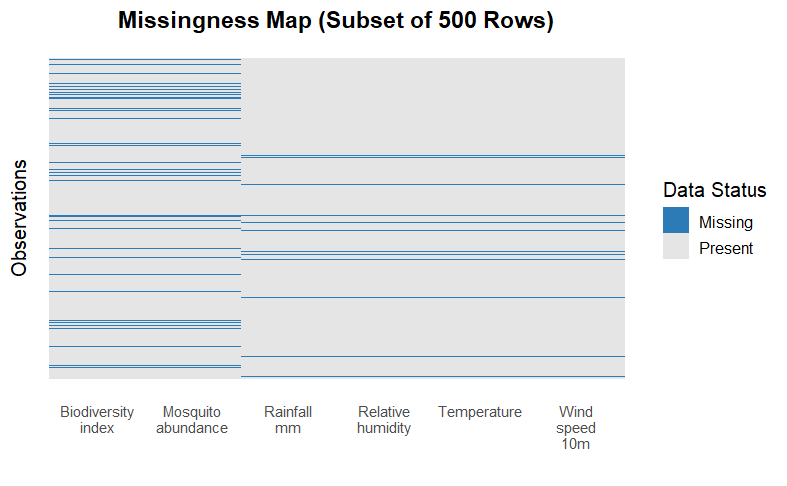

```r
# Missingness heatmap for main variables

p1 <- df_final %>%
  slice_sample(n = 500) %>%
  dplyr::select(Temperature, Relative_humidity, Wind_speed_10m, Rainfall_mm,
         Mosquito_abundance, Biodiversity_index) %>%
  naniar::vis_miss(sort_miss = TRUE) +
  ggtitle("Missingness Map (Subset of 500 Rows)") +
  scale_fill_manual(values = c("grey90", "#2c7bb6"),
                    name = "Data Status",
                    labels = c("Present", "Missing")) +
  scale_x_discrete(labels = function(x) gsub("_", "\n", x)) +
  theme_minimal(base_size = 13) +
  theme(
    axis.text.x = element_text(size = 10),
    axis.text.y = element_blank(),
    axis.ticks.y = element_blank(),
    panel.grid = element_blank(),
    plot.title = element_text(face = "bold", hjust = 0.5)
  )
# 2) Missingness rate by Rainfall
mar_rates <- df_final %>%
  mutate(Missing_abundance = is.na(Mosquito_abundance)) %>%
  # Create bins
  mutate(Rainfall_bin = case_when(
    is.na(Rainfall_mm) ~ "NA",
    Rainfall_mm <= 1 ~ "≤1",
    Rainfall_mm <= 5 ~ "(1,5]",
    Rainfall_mm <= 10 ~ "(5,10]",
    Rainfall_mm <= 20 ~ "(10,20]",
    Rainfall_mm <= 50 ~ "(20,50]",
    TRUE ~ ">50"
  )) %>%
  # Convert to factor with proper order
  mutate(Rainfall_bin = factor(Rainfall_bin,
                               levels = c("≤1", "(1,5]", "(5,10]", "(10,20]", "(20,50]", ">50", "NA"))) %>%
  group_by(Rainfall_bin) %>%
  summarize(n = n(), miss_rate = mean(Missing_abundance, na.rm = TRUE), .groups = "drop")

p2 <- ggplot(mar_rates, aes(x = Rainfall_bin, y = miss_rate)) +
  geom_col() +
  labs(x = "Rainfall (binned, mm)",
       y = "Missingness rate for Mosquito_abundance",
       title = "Missingness rate vs Rainfall (MAR expected)") +
  theme_minimal() +
  theme(
    panel.grid.major.x = element_blank()
  )

# 3) Missingness vs true Mosquito_abundance
mnar_df <- df_final %>%
  mutate(true_ab = Mosquito_abundance_orig,
         missing_ab = is.na(Mosquito_abundance))

# Create fewer, more meaningful bins
mnar_plot_df <- mnar_df %>%
  filter(!is.na(true_ab)) %>%
  mutate(ab_bin = cut(true_ab,
                      breaks = c(0, 5, 10, 20, 50, 100, 200, Inf),  # Wider bins
                      labels = c("0-5", "6-10", "11-20", "21-50",
                                "51-100", "101-200", ">200"),
                      include.lowest = TRUE)) %>%
  group_by(ab_bin) %>%
  summarize(mean_ab = mean(true_ab, na.rm = TRUE),
            miss_rate = mean(missing_ab),
            n_obs = n(),  # Count observations per bin
            .groups = "drop") %>%
  filter(n_obs >= 10)  # Only keep bins with at least 10 observations

p3 <- ggplot(mnar_plot_df, aes(x = ab_bin, y = miss_rate)) +
  geom_point(size = 3) +
  geom_line(aes(group = 1), linewidth = 1) +
  labs(x = "True abundance (binned)",
       y = "Missingness rate",
       title = "Missingness rate vs True mosquito abundance (MNAR)") +
  theme_minimal(base_size = 13) +
  theme(
    axis.text.x = element_text(angle = 45, hjust = 1, vjust = 1),
    plot.title = element_text(face = "bold", hjust = 0.5),
    panel.grid.minor = element_blank()
  )

# Display plots
print(p1)
```

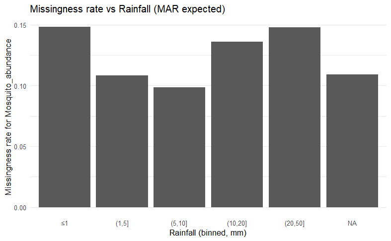

```r
print(p2)
```

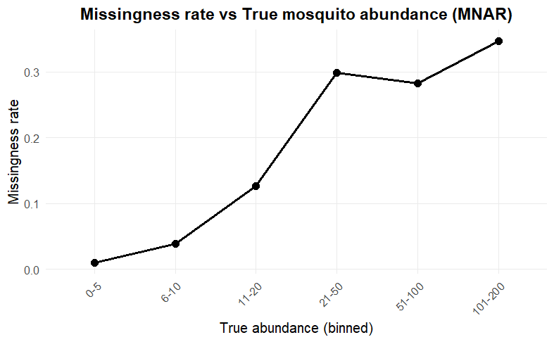

```r
print(p3)
```

The missingness is purely random, simulating data loss due to hardware failure. There should be no systematic pattern related to other variables. Missingness is imposed in mosquito abundance and biodiversity based on observed rainfall and wind speed. This simulates traps failing more often in heavy rain or high winds.

```r
# Tests
# 1) Test for MCAR: Little's MCAR test (


cat("\n--- Little's MCAR test (on weather vars) ---\n")
```

```
--- Little's MCAR test (on weather vars) ---
```

```r
little_input <- df_final %>%
  dplyr::select(Temperature, Relative_humidity, Wind_speed_10m, Rainfall_mm,
         Green_area_coverage, Blue_area_coverage)

res_little <- tryCatch({
  mcar_test(little_input)
}, error = function(e) {
  message("Little's MCAR test failed: ", e$message)
  return(NULL)
})
print(res_little)
```

| statistic | df | p.value | missing.patterns |
| --- | --- | --- | --- |
| 1.808997e-27 | 0 | 0 | 2 |

```r
# 2) Test for MAR: logistic regression predicting trapfail_MAR by Rainfall (observable)
cat("\n--- Logistic regression: MAR test (trapfail_MAR ~ Rainfall_mm + Wind_speed_10m) ---\n")
```

```
--- Logistic regression: MAR test (trapfail_MAR ~ Rainfall_mm + Wind_speed_10m) ---
```

```r
glm_mar <- glm(trapfail_MAR ~ Rainfall_mm + Wind_speed_10m, data = df_final, family = binomial)
summary(glm_mar)
```

```
Call:
glm(formula = trapfail_MAR ~ Rainfall_mm + Wind_speed_10m, family = binomial,
    data = df_final)

Coefficients:
                Estimate Std. Error z value Pr(>|z|)
(Intercept)    -3.172782   0.189388 -16.753   <2e-16 ***
Rainfall_mm     0.130763   0.007452  17.547   <2e-16 ***
Wind_speed_10m  0.016520   0.034557   0.478    0.633
---
Signif. codes:  0 ‘***’ 0.001 ‘**’ 0.01 ‘*’ 0.05 ‘.’ 0.1 ‘ ’ 1

(Dispersion parameter for binomial family taken to be 1)

    Null deviance: 2567.8  on 2151  degrees of freedom
Residual deviance: 2159.2  on 2149  degrees of freedom
  (101 observations deleted due to missingness)
AIC: 2165.2

Number of Fisher Scoring iterations: 4
```

```r
# Show effect (odds ratios)
exp(cbind(OR = coef(glm_mar), confint(glm_mar)))
```

[output not shown]

```
                       OR      2.5 %     97.5 %
(Intercept)    0.04188692 0.02872042 0.06036088
Rainfall_mm    1.13969710 1.12344704 1.15676546
Wind_speed_10m 1.01665677 0.95001019 1.08789644
```

```r
# 3) MNAR: can't be tested with observed data alone (since it depends on unobserved values).
# We'll run a sensitivity analysis by varying delta and observing the effect on mean Mosquito_abundance estimates.

# Sensitivity analysis function: impose MNAR with different deltas, compute naive mean and imputed mean (mice)
sensitivity_results <- data.frame(delta = numeric(), prop_missing = numeric(),
                                  mean_obs = numeric(), mean_mi = numeric(), stringsAsFactors = FALSE)

deltas <- seq(-2, 4, by = 1)  # vary delta from -2 to +4 (negative reduces MNAR, positive increases)
for (d in deltas) {
  df_sens <- impose_MNAR(df_mar, delta = d, propcap = 0.45) # on top of earlier MAR/MCAR states
  # compute proportion missing
  pmiss <- mean(is.na(df_sens$Mosquito_abundance_MNAR))
  # naive observed mean (complete-case)
  mean_obs <- mean(df_sens$Mosquito_abundance_MNAR, na.rm = TRUE)
  # multiple imputation with mice (predictive mean matching) for a simple corrected mean
  # Use a small number of imputations for speed
  mi_input <- df_sens %>%
    dplyr::select(Mosquito_abundance_MNAR, Green_level, Rainfall_mm, Temperature, Trap_type) %>%
    rename(Mosq = Mosquito_abundance_MNAR)
  # mice needs factor variables encoded
  mi_input$Trap_type <- as.factor(mi_input$Trap_type)
  mi_input$Green_level <- as.factor(mi_input$Green_level)
  imp <- tryCatch({
    mice::mice(mi_input, m = 5, method = "pmm", seed = 2023, printFlag = FALSE)
  }, error = function(e) {
    NULL
  })
  mean_mi <- NA
  if (!is.null(imp)) {
    comp <- mice::complete(imp, "long", include = TRUE)
    # compute pooled mean of Mosq across imputations
    mean_by_imp <- comp %>%
      filter(.imp != 0) %>%
      group_by(.imp) %>%
      summarize(mean_imp = mean(Mosq, na.rm = TRUE))
    mean_mi <- mean(mean_by_imp$mean_imp, na.rm = TRUE)
  }
  sensitivity_results <- rbind(sensitivity_results,
                               data.frame(delta = d, prop_missing = pmiss,
                                          mean_obs = mean_obs, mean_mi = mean_mi))
}

# Also compute the true mean from the complete truth for comparison
true_mean <- mean(truth$Mosquito_abundance, na.rm = TRUE)
cat("\nTrue mean (no missingness):", true_mean, "\n")
```

```
True mean (no missingness): 21.1984
```

```r
print(sensitivity_results)
```

| delta | prop_missing | mean_obs | mean_mi |
| --- | --- | --- | --- |
| -2 | 0.1318242 | 16.21524 | 17.94683 |
| -1 | 0.1509099 | 17.05332 | 17.94905 |
| 0 | 0.2001775 | 16.58935 | 17.84012 |
| 1 | 0.2294718 | 17.30242 | 18.58118 |
| 2 | 0.2818464 | 17.56922 | 18.78686 |
| 3 | 0.3528628 | 18.16667 | 19.03178 |
| 4 | 0.4025743 | 20.17236 | 20.54106 |

[figure not shown]

```r
# Plot sensitivity: observed mean and MI mean vs delta with true mean line
s_plot <- sensitivity_results %>%
  pivot_longer(cols = c("mean_obs", "mean_mi"), names_to = "estimator", values_to = "mean_est")

ggplot(s_plot, aes(x = delta, y = mean_est, color = estimator)) +
  geom_point() + geom_line() +
  geom_hline(yintercept = true_mean, linetype = "dashed") +
  labs(title = "MNAR sensitivity: estimated mean abundance vs MNAR strength (delta)",
       y = "Estimated mean Mosquito_abundance", x = "delta (MNAR strength)") +
  scale_color_discrete(name = "Estimator", labels = c("Observed mean (complete-case)", "MI pooled mean")) +
  theme_minimal()
```

```r
# Save sensitivity table
print(sensitivity_results)
```

| delta | prop_missing | mean_obs | mean_mi |
| --- | --- | --- | --- |
| -2 | 0.1318242 | 16.21524 | 17.94683 |
| -1 | 0.1509099 | 17.05332 | 17.94905 |
| 0 | 0.2001775 | 16.58935 | 17.84012 |
| 1 | 0.2294718 | 17.30242 | 18.58118 |
| 2 | 0.2818464 | 17.56922 | 18.78686 |
| 3 | 0.3528628 | 18.16667 | 19.03178 |
| 4 | 0.4025743 | 20.17236 | 20.54106 |

Regression summary: | Variable | Estimate | Std. Error | z value | Pr(>|z|) | OR (95% CI) | |—————-|———–|————|———|———–|————-| | Intercept | -3.173 | 0.189 | -16.753 | <2e-16 | 0.042 (0.029–0.060) | | Rainfall_mm | 0.131 | 0.007 | 17.547 | <2e-16 | 1.14 (1.12–1.16) | | Wind_speed_10m | 0.0165 | 0.035 | 0.478 | 0.633 | 1.02 (0.95–1.09) |

Rainfall_mm has a significant positive effect (p < 0.001). For each 1 mm increase in rainfall, the odds of trap failure increase by ~14%.

Wind_speed_10m is not statistically significant (p = 0.633), suggesting wind had little impact on trap failure in this dataset.

The logistic regression confirms the MAR mechanism: missingness in Mosquito_abundance is related to the observable variable Rainfall_mm, consistent with how we simulated MAR.

True mean (no missingness) = 21.1984

Mean observed values increase slightly with proportion of missingness (mean_obs vs mean_mi), indicating that missing data could bias the mean if not addressed.

As missingness increases (bins -2 to 3), the observed mean slightly underestimates the true mean.

Multiple imputation or other strategies would be necessary to reduce bias when analyzing the final dataset.